# Auxiliar 08 - Más aplicaciones del Laplaciano, con libigl

### CC5513 - Procesamiento Geométrico y Análisis de Formas

## Objetivo/Contexto

En este auxiliar, veremos algunas cosas que se pueden hacer con la librería libigl, una librería para realizar procesamiento geométrico. Como tiene bindings en python, podemos seguir usando este lenguaje. Algo que no habíamos visto en acción y que podremos experimentar con esta librería, son las deformaciones.

Archivo inicial

```python
# Igual que siempre, hay que correr los archivos en su local debido a que polyscoope no se puede lanzar en collab
# Pero dejo comentado cosas que tendrían que instalar para Libigl

#!python -m pip install libigl
#!python -m pip install https://github.com/skoch9/meshplot/archive/0.4.0.tar.gz
#!python -m pip install matplotlib
#!python -m pip install pythreejs
import igl
import scipy as sp
import numpy as np
import openmesh
import polyscope as ps
from meshplot import plot, subplot, interact
import os

root_folder = ""

from scipy.sparse import *
from scipy.sparse.linalg import eigs, spsolve
```

Trabajaremos con los datos que se encuentran en https://github.com/libigl/libigl-tutorial-data almecenados en una carpeta `data`.

Los códigos que se mostrarán fueron adaptados de los tutoriales oficiales de https://libigl.github.io/libigl-python-bindings/

Se modificaron para poder trabajar en conjunto con polyscope (por si tuvieran problemas con meshplot), así como que se cambió `igl.harmonic` por `igl.harmonic_weights`, ya que el escrito en el tutorial no funcionaba. Pero pueden probar directamente los tutoriales si les funciona.

## Curvaturas

```python
v, f = igl.read_triangle_mesh("cat0.off")
m = igl.massmatrix(v, f, igl.MASSMATRIX_TYPE_VORONOI)
minv = sp.sparse.diags(1 / m.diagonal())
```

Durante su primera tarea, trabajaron con un método para calcular la curvatura media. Teóricamente, vimos que este valor podía ser calculado tomando el promedio entre la curvatura máxima $k_1$ y la curvatura mínima $k_2$. Este es, de hecho, un resultado de calcular el promedio de todas las curvaturas posibles en un punto.

Consideremos un manifold, donde en un determinado punto de interés tenemos asociada su normal $n$, y las dos direcciones ($e_1$ y $e_2$) de las tangentes principales desde donde existen la curvatura máxima y la curvatura mínima. Podemos entoncer formar planos perpendiculares al plano tangente, formados por la normal y una combinación lineal de $e1$ y $e2$. En la siguiente imagen podemos ver esta idea, donde vemos que podemos ir girando nuestro plano perpendicular dado un ángulo $\theta$.

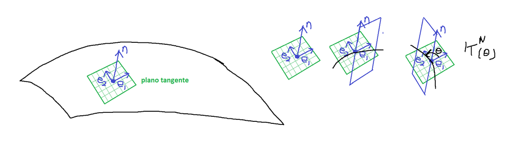

$K^n(\theta)$ es, entonces, la curvatura de nuestra manifold en un punto, al considerar su normal y el ángulo en torno al cuál estamos viendo su curvatura. La curvatura Gaussiana sabemos que podemos calcularla con el producto de las dos curvaturas principales.

$$ k_G = k_1k_2 $$

```python
k = igl.gaussian_curvature(v, f)  # libigl provee una función para obtener la curvatura gaussiana en toda la malla
kn = minv.dot(k)
```

La curvatura media sabemos que podemos calcularla con el promedio de las dos curvaturas principales. En realidad, podemos calcularla de promediar las infinitas curvaturas que hay en ese punto, considerando los infinitos ángulos desde donde mirar la curvatura. Esto lo podemos hacer integrando las curvaturas sobre un círculo unitario, dividiendo por su perímetro.

$$ k_H = \frac{1}{2\pi}\int_0^{2\pi}k^N(\theta)d\theta = \frac{1}{2\pi}\int_0^{2\pi}(k_1 \cos(x)^2+k_2 \sin(x)^2)d\theta\\ = \frac{1}{2\pi}\int_0^{2\pi}\left((\cos(x)^2+\sin(x)^2\right)k_1 + (k_2-k_1) \sin(x)^2d\theta\\ = \frac{1}{2\pi}\int_0^{2\pi}\left(k_1 + (k_2-k_1) \sin(x)^2\right)d\theta\\ = \dfrac{\left(k_2+k_1\right)x}{4\pi}\bigg|_0^{2\pi} + \frac{\left(k_1-k_2\right)\cos\left(x\right)\sin\left(x\right)}{4\pi}\bigg|_0^{2\pi} \\ = \frac{k_2 + k_1}{2} $$

Existe un resultado, sin embargo, que nos permite obtener la curvatura media al utilizar el operador laplaciano. [Por si quieren leer](http://multires.caltech.edu/pubs/diffGeoOps.pdf)

$$ \Delta v = (M^{-1}L)v = -Hn \\ $$

```python
l = igl.cotmatrix(v, f)  # Laplaciano utilizando las contangentes
hn = -minv.dot(l.dot(v))
h = np.linalg.norm(hn, axis=1)
```

Ahora que tenemos nuestras curvaturas gaussiana y media, podemos mostrarlas con polyscope igual que hemos hecho otras veces. Pero además de eso, aprovecharemos que libigl nos permite obtener las direcciones principales, y lo usaremos para mostrarlas en nuestra pantalla.

```python
v1, v2, k1, k2 = igl.principal_curvature(v, f)
h2 = 0.5 * (k1 + k2)  # no usaremos esto en realidad, pero pueden compararlo por el resultado obtenido con el laplaciano
```

```python
avg = igl.avg_edge_length(v, f) / 2.0  # Usaremos esto para mostrar ($e_1$ x $e-2$) de este tamaño en cada punto de la malla
# Para cada $e_i$, mostraremos un segmento.
# Esto lo haremos tomando un vértice v, y sumándole la dirección $e_i$ correspondiente (escalada por avg para que quede de un buen tamaño)
# Al sumar la dirección, obtenemos un punto del segmento, y al restar la dirección obtenemos el otro.
curve1_nodes = np.concatenate((v + v1 * avg, v - v1 * avg))  # e_1. Concatenamos los extremos de los segmentos
curve2_nodes = np.concatenate((v + v2 * avg, v - v2 * avg))  # e_2. Concatenamos los extremos de los segmentos.

# Unimos los nodos.
curve_edges = np.array([[i, i+v.shape[0]] for i in range(len(v))])
```

```python
ps.init()
ps_mesh = ps.register_surface_mesh('Cat', v, f, edge_width=1)
ps_mesh.add_scalar_quantity('Gaussian Curvature', k)
ps_mesh.add_scalar_quantity('Integral average', kn)
ps_mesh.add_scalar_quantity('Mean Curvature', h)

ps.register_curve_network("curve1", curve1_nodes, curve_edges, radius=0.0003)
ps.register_curve_network("curve2", curve2_nodes, curve_edges, radius=0.0003)

ps.show()
```

### Parametrización

Al igual que en su tarea 3, podemos utilizar el laplaciano para parametrizar. Con ligigl, resulta bastante directo.

#### Armónica

```python
v, f  = igl.read_triangle_mesh(os.path.join(root_folder, "data", "camelhead.off"))
## Find the open boundary
bnd = igl.boundary_loop(f)

## Map the boundary to a circle, preserving edge proportions
bnd_uv = igl.map_vertices_to_circle(v, bnd)

## Harmonic parametrization for the internal vertices
uv = igl.harmonic_weights(v, f, bnd, bnd_uv, 1)
v_p = np.hstack([uv, np.zeros((uv.shape[0],1))])


ps.init()
ps_mesh = ps.register_surface_mesh('camelhead', v, f, edge_width=1)
ps_mesh.add_parameterization_quantity('uv', uv, defined_on='vertices')

ps_mesh_flat = ps.register_surface_mesh('camelhead_param', v_p, f, edge_width=1)
ps_mesh_flat.add_parameterization_quantity('uv', uv, defined_on='vertices')

ps.show()

#p = subplot(v, f, uv=uv, shading={"wireframe": False, "flat": False}, s=[1, 2, 0])
#subplot(v_p, f, uv=uv, shading={"wireframe": True, "flat": False}, s=[1, 2, 1], data=p)
```

#### As-rigid-as-possible

La gracia de este tipo de parametrización es que intenta preservar distancias (y por lo tanto ángulos). Intenta preservar en ese sentido la forma de los triángulos, por lo que la textura de la parametrización se verá con los cuadrados más regulares en el objeto original, pero deformados en el objeto circular aplanado.

```python
arap = igl.ARAP(v, f, 2, np.zeros(0))
uva = arap.solve(np.zeros((0, 0)), uv)

ps_mesh.add_parameterization_quantity('uva', uva, defined_on='vertices')

ps_mesh_flat.add_parameterization_quantity('uva', uva, defined_on='vertices')

ps.show()
#p = subplot(v, f, uv=uva, shading={"wireframe": False, "flat": False}, s=[1, 2, 0])
#p = subplot(uva, f, uv=uva, shading={"wireframe": False, "flat": False}, s=[1, 2, 1], data=p)
```

### Deformación

libigl nos permite trabajar con deformaciones. Para ello, esta vez aparte del objeto que queremos deformar, necesitamos decir qué vértices queremos mantener fijos, cuáles vamos a mover, y cuáles se moverán en el camino.

Cargaremos un archivo con esta información. Este archivo contiene sólo valores que pueden ser {-1, 0, 1 o 2}, indicando qué haremos con los vértices. Con esto podemos preparar las condiciones de borde.

```python
v, f = igl.read_triangle_mesh("decimated-max.obj")
v[:,[0, 2]] = v[:,[2, 0]] # Swap X and Z axes
u = v.copy()

s = igl.read_dmat("decimated-max-selection.dmat")
b = np.array([[t[0] for t in [(i, s[i]) for i in range(0, v.shape[0])] if t[1] >= 0]]).T

## Boundary conditions directly on deformed positions
u_bc = np.zeros((b.shape[0], v.shape[1]))
v_bc = np.zeros((b.shape[0], v.shape[1]))

for bi in range(b.shape[0]):
    v_bc[bi] = v[b[bi]]

    if s[b[bi]] == 0: # Don't move handle 0
        u_bc[bi] = v[b[bi]]
    elif s[b[bi]] == 1: # Move handle 1 down
        u_bc[bi] = v[b[bi]] + np.array([[0, -50, 0]])
    else: # Move other handles forward
        u_bc[bi] = v[b[bi]] + np.array([[-25, 0, 0]])
```

Con esta información, podremos finalmente deformar la malla. Esto lo haremos tres veces, registrando la superficie obtenida en polyscope para mostrarla.

```python
ps.init()
ps_mesh = ps.register_surface_mesh('Decimated-max', v, f, edge_width=1)
ps_mesh.add_scalar_quantity('selection', s)

for i in range(3):
    u_bc_anim = v_bc + i*0.6 * (u_bc - v_bc)
    d_bc = u_bc_anim - v_bc
    d = igl.harmonic_weights(v, f, b, d_bc, 2)
    u = v + d
    ps_o = ps.register_surface_mesh('Decimated-max deformed'+str(i), u, f)
    ps_o.add_scalar_quantity('selection', s)

ps.show()
```